# Estimando indices de accesibilidad a espacios verdes para ciudades de la Argentina

Antonio Vázquez Brust

6/15/2019

```r
library(tidyverse)
library(sf)
```

### El acceso a espacios verdes como determinante de la salud

Se conoce la relación entre disponibilidad de espacios verdes urbanos y salud pública.

Existe una literature review de la OMS Investigaciones que han encontrado relación entre el acceso a espacios verdes y la salud: http://www.euro.who.int/__data/assets/pdf_file/0005/321971/Urban-green-spaces-and-health-review-evidence.pdf

La review identifica estándares respecto a que puede considerarse un “espacio verde”. Se definió un estándar para Inglaterra, *Accessible Natural Greenspace Standard for England*, que recomienda para todos los habitantes del país el acceso a espacios verdes públicos:

• at least 2 hectares in size, no more than 300 m linear distance (5 minutes’ walk) from home; • least one accessible 20 hectare (ha) site within two kilometres of home; • one accessible 100 ha site within five kilometres of home;  
• one accessible 500 ha site within ten kilometres of home; and • a minimum of one ha of statutory Local Nature Reserves per thousand population.

Por otra parte, la Unión Europea definió entre sus indicadores de sustentabilidad una recomendación más laxa. La sustentabilidad de las ciudades, respecto a su acceso a espacios verdes, se mide como

the percentage of citizens living within 300 m from a public open area of minimum size 0.5 hectares

Indicadores Europeos de Sustentaibilidad: https://www.gdrc.org/uem/footprints/eci_final_report.pdf

## Los datos

### OpenStreetMap

Un estudio utilizó datos de OSM para identificar espacios verdes. Asi pudo evaluar la correlación entre cercanía de mujeres embarazadas a espacios verdes y características de nacimiento como peso, edad gestacional, prematurez, etc.

Green spaces and adverse pregnancy outcomes https://oem.bmj.com/content/71/8/562.full

Detalles de OSM para la identificación de espacios verdes https://wiki.openstreetmap.org/wiki/Key:leisure

```r
library(osmdata)

bbox = getbb('Ciudad Autonoma de Buenos Aires')
bbox
```

```
##         min       max
## x -58.53146 -58.33512
## y -34.70564 -34.52655
```

```r
bbox_poly = getbb('Ciudad Autonoma de Buenos Aires', format_out = "sf_polygon")
bbox_poly
```

```
## Simple feature collection with 1 feature and 0 fields
## geometry type:  POLYGON
## dimension:      XY
## bbox:           xmin: -58.53146 ymin: -34.70564 xmax: -58.33512 ymax: -34.52655
## epsg (SRID):    4326
## proj4string:    +proj=longlat +datum=WGS84 +no_defs
##                         geometry
## 1 POLYGON ((-58.53146 -34.615...
```

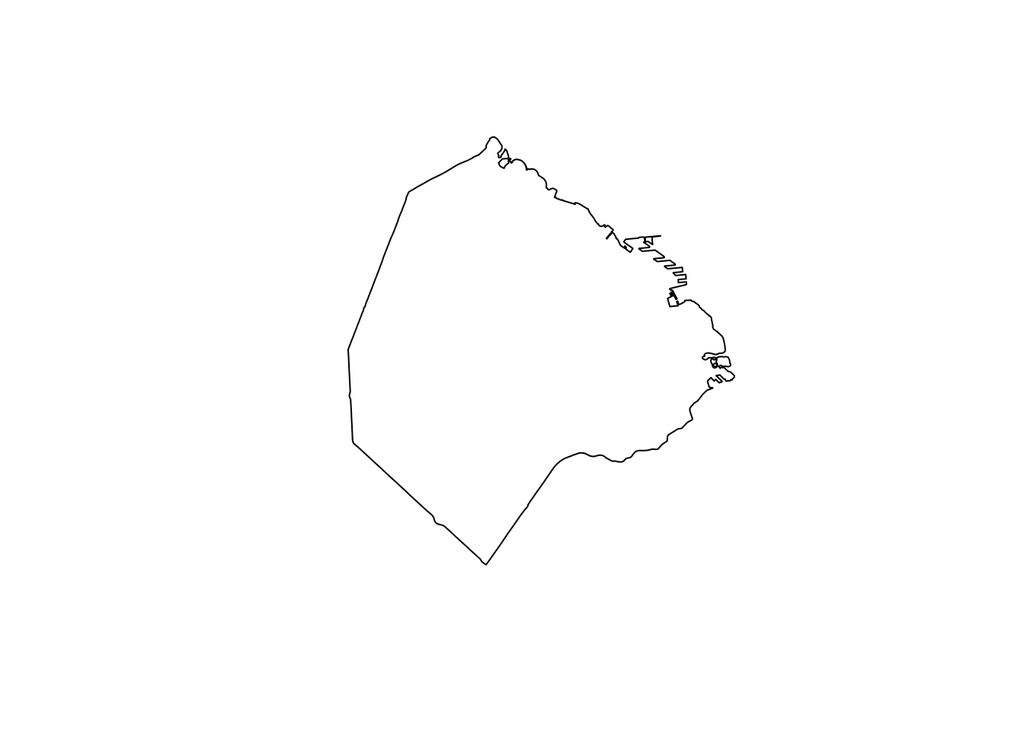

```r
plot(bbox_poly)
```

opq() realiza una consulta a overpass (http://overpass-api.de/), la interfaz para extraer información de la base de datos global de OpenStreetMap. Usa bounding boxes rectangulares (no poligonales)

Con add_osm_feature() especificamos que datos queremos descargar. Aquí vamos a solicitar espacios públicos (parques, plazas, etc), que en base de datos de OpenStreetMap tienen la clave “leisure” con valores como “garden”, “nature_reserve”, “park”). Ver https://wiki.openstreetmap.org/wiki/Key:leisure

En OSM una “key” puede interpretarse como una categoría general -en el caso de “leisure”, la recreación- y sus posibles “values” son subcategorías más específicas, como “garden”, “nature_reserve”, “park”.

```r
parques <- opq(bbox) %>%
    add_osm_feature(key = "leisure", value = c("garden", "nature_reserve", "park"))

parques
```

```
## $bbox
## [1] "-34.705637,-58.5314588,-34.5265535,-58.3351249"
##
## $prefix
## [1] "[out:xml][timeout:25];\n(\n"
##
## $suffix
## [1] ");\n(._;>;);\nout body;"
##
## $features
## [1] " [\"leisure\"~\"^(garden|nature_reserve|park)$\"]"
##
## attr(,"class")
## [1] "list"           "overpass_query"
```

Por ahora no contiene ningún dato espacial. Es sólo la definición de una consulta a la base de datos de OpenStreetMap: “Todas los espacios verdes (objetos con clave”leisure" y valores “garden”, “nature_reserve”, o “park” dentro de los límites de la CABA"

Para hacer efectiva la consulta y descargar los datos, solicitamos un objeto espacial, de tipo sf, conteniendo los resultados

La descarga de información para una ciudad grande puede tomar varios minutos, y más aún la de un área metropolitana (o país, o continente, etc)

```r
parques <- parques %>%
    osmdata_sf()

# Tenemos parques!
parques
```

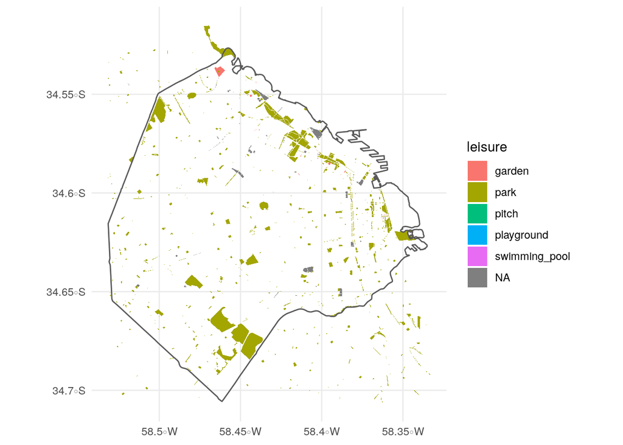

```r
parques$osm_polygons %>%
  ggplot() +
  geom_sf(aes(fill = leisure), color = NA) +
  geom_sf(data = bbox_poly, fill = NA) +
  theme_minimal()
```

Falta la reserva ecológica!

Hay una discusión relevante en la Wiki de OSM para el tag leisure:

boundary=protected_area is a more recently introduced tag with a more verbose tagging scheme which can deal with all kind of protections and protection levels. It attempts to encompass both nature reserves and national parks, and is used more and more.

boundary=national_park is a form of protected area. Like a nature reserve it is about protecting wildlife etc, and is normally designated by a government. The distinction is unclear and is under discussion, but some suggestions are: nature reserves are smaller areas than national parks. National parks are rather like administrative boundaries around large areas whereas nature reserves are more evident on-the-ground. National parks are often named “X national park”, and are in some sense officially proclaimed a national park.

```r
areas_protegidas <- opq(bbox) %>%
  add_osm_feature(key = "boundary", value = c("protected_area", "national_park"))
```

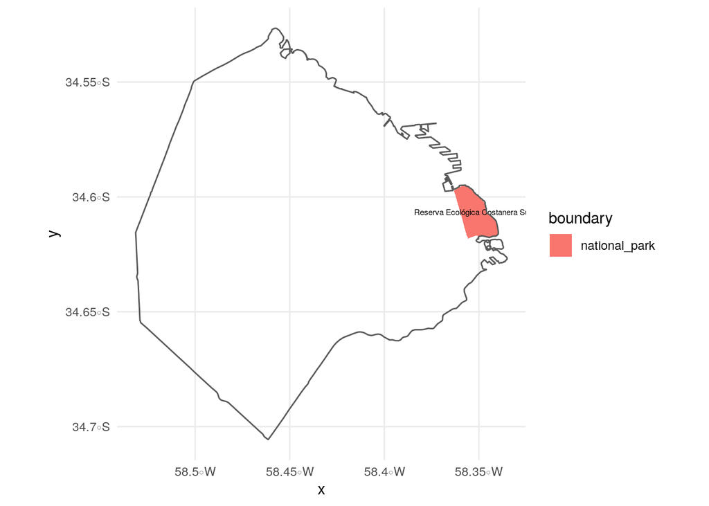

```r
areas_protegidas <- areas_protegidas %>%
    osmdata_sf()

areas_protegidas$osm_polygons %>%
  ggplot() +
  geom_sf(aes(fill = boundary), color = NA) +
  geom_sf_text(aes(label = name), size = 2) +
  geom_sf(data = bbox_poly, fill = NA) +
  theme_minimal()
```

Tenemos que

- I. Unir todos los conjuntos en uno solo: polígonos y multipolígonos del query de parques, junto con poligonos y multipoligonos del query de áreas protegidas
- 2. Extender los polígonos unos metros en torno a si mismos, de manera que “toquen” con los polígonos más cercanos. Esto es útil para unificar parques y otras áreas verdes atravesadas por calles; si no extendiéramos sus polígonos para que se solapen, serían interpretados como áreas separadas en nuestro posterior análisis.
- 3. Unir los polígonos. Así evitamos que “parques dentro de parques” y otras áreas conceńtricas aparezcan sumando sus m2, cuando en realidad sólo necesitamos contar los metros de superficia cubierta por el conjunto unido. (es decir, evitar que un polígono de 1 km2 interno a otro de 10 km2 resulte en un total de 11 km2 cubiertos, cuando en realidad son sólo 10)

### - I. Unir todos los conjuntos en uno solo

```r
areas_verdes <- map_if(list(parques$osm_polygons,
                            parques$osm_multipolygons,
                            areas_protegidas$osm_polygons,
                            areas_protegidas$osm_multipolygons),
                       negate(is.null),
                       select, geometry) %>%
  reduce(rbind)
```

### II. Extender los polígonos de manera que se “toquen” con los más cercanos

```r
areas_verdes <- areas_verdes %>%
  st_transform(crs = "+proj=laea +lat_0=-40 +lon_0=-60 +x_0=0 +y_0=0 +ellps=WGS84 +units=m +no_defs")
```

Generamos un *buffer* de 10 metros, y unimos

```r
areas_unificadas <- st_buffer(areas_verdes, 10) %>%
  st_union() %>%
  st_cast("POLYGON") %>%
  st_sf() %>%
  mutate(id = factor(row_number()))
```

Con eso podemos etiquetar a los espacios verdes originales con el id que los agrupa:

```r
areas_verdes <- areas_verdes %>%
  st_join(areas_unificadas) %>%
  lwgeom::st_make_valid() %>% #sin esto, el summarise() falla con un error de topología inválida
  group_by(id) %>%
  summarise()
```

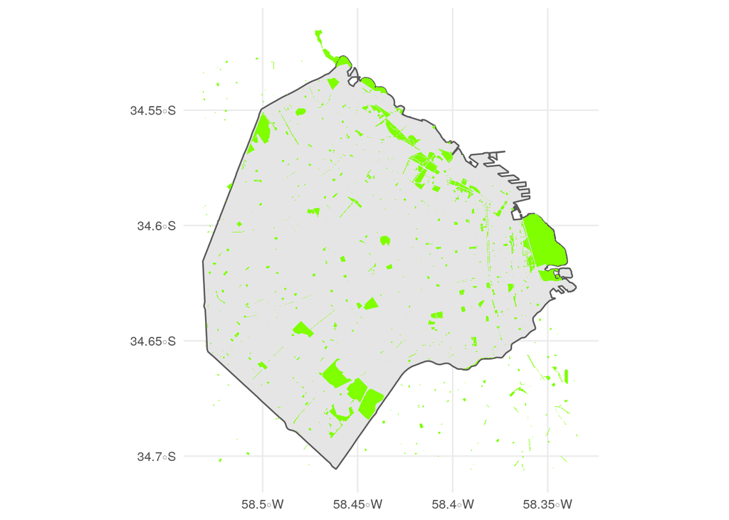

```r
ggplot() +
  geom_sf(data = bbox_poly) +
  geom_sf(data = areas_verdes, fill = "chartreuse", color = NA) +
  theme_minimal()
```

#### Ahora para toda la Argentina

```r
bbox <- getbb('Argentina', featuretype = "country")

arg_borders <- st_read("../../Datasets/IGN/Provincias/Provincias.shp") %>%
  summarise()

plot(arg_borders)

#La opcion memsize = 2000000000 permite usar el maximo de memoria en los servidores de OSM
#para procesar la consulta

areas_verdes <- opq(bbox, memsize = 2000000000) %>%
  add_osm_feature(key = "leisure", value = c("garden", "nature_reserve", "park")) %>%
  add_osm_feature(key = "boundary", value = c("protected_area", "national_park"))

areas_verdes <- areas_verdes %>%
    osmdata_sf()
```

Imposible! El query de parques falla con este mensaje:

Error in check_for_error(doc) : General overpass server error; returned: The data included in this document is from www.openstreetmap.org. The data is made available under ODbL. runtime error: Query timed out in “recurse” at line 8 after 26 seconds.

Camino alternativo:

Descargaremos en export de todos los datos que tiene OSM para la Argentina, via GEOFABRIK: https://download.geofabrik.de/south-america/argentina.html

```r
# la capa "natural" no tiene nada util para nuestro caso; sus categorias son
# beach cave_entrance         cliff          peak        spring          tree       volcano
#
# natural <- st_read("../../../data/Arg/gis_osm_natural_free_1.shp", stringsAsFactors = F) %>%
#   rbind(st_read("../../../data/Arg/gis_osm_natural_free_1.shp", stringsAsFactors = F))
areas_verdes <- st_read("../../../data/Arg/gis_osm_landuse_a_free_1.shp",
                        stringsAsFactors = F) %>%
  filter(fclass %in% c("nature_reserve", "park")) %>%
  select(-code)

# Al 18 jun 2019, la capa de land use no icluye a la Reserva Ecologica.
# Exigimos la presencia de la Reserva Ecologica!
# la traemos

library(osmdata)

reserva <- 'Ciudad Autonoma de Buenos Aires' %>%
  getbb() %>%
  opq() %>%
  add_osm_feature(key = "boundary", value = c("national_park")) %>%
  osmdata_sf() %>%
  .[["osm_polygons"]] %>%
  transmute(osm_id,
            fclass = "nature_reserve",
            name)

# la agregamos

areas_verdes <- areas_verdes %>%
  rbind(reserva)


### Retenemos sólo espacios mayores a media hectárea

areas_verdes <- areas_verdes %>% # Pasamos a proyección equiareal para una medición precisa de áreas
  filter(as.numeric(st_area(st_transform(., crs = "+proj=laea +lat_0=-40 +lon_0=-60 +x_0=0 +y_0=0 +ellps=WGS84 +units=m +no_defs"))) > 5000)

# Guardamos el resultdo

#st_write(areas_verdes, "../../Datasets/ambiente/areas_verdes_argentina.geojson", delete_dsn = TRUE)

### Si queremos combinar las areas que estan muy proximas entre si
### (a menos de 20m en este caso)

# Proyección equiareal
areas_verdes <- areas_verdes %>%
  st_transform(crs = "+proj=laea +lat_0=-40 +lon_0=-60 +x_0=0 +y_0=0 +ellps=WGS84 +units=m +no_defs")

# Generamos un _buffer_ de 10 metros, y unimos
areas_unificadas <- st_buffer(areas_verdes, 10) %>%
  st_union() %>%
  st_cast("POLYGON") %>%
  st_sf() %>%
  mutate(id = factor(row_number()))


areas_verdes <- areas_verdes %>%
  st_join(areas_unificadas) %>%
  lwgeom::st_make_valid() %>% #sin esto, el summarise() falla con un error de topología inválida
  group_by(id) %>%
  summarise()
```

### Aglomerados urbanos según INDEC

Descargados de la [Base geográfica Encuesta Permanente de Hogares](https://www.indec.gob.ar/nivel4_default.asp?id_tema_1=1&id_tema_2=39&id_tema_3=120)

```r
ciudades <- st_read("../../Datasets/INDEC/EPH/radios_eph.json") %>%
    st_transform(4326)
```

```
## replacing null geometries with empty geometries
## Simple feature collection with 26815 features and 14 fields (with 3 geometries empty)
## geometry type:  MULTIPOLYGON
## dimension:      XY
## bbox:           xmin: 3219646 ymin: 3918704 xmax: 4511982 ymax: 7342026
## epsg (SRID):    22183
## proj4string:    +proj=tmerc +lat_0=-90 +lon_0=-66 +k=1 +x_0=3500000 +y_0=0 +ellps=WGS84 +towgs84=0,0,0,0,0,0,0 +units=m +no_defs
```

```r
library(ggspatial)

# Vemos los nombres de los aglomerados
unique(ciudades$eph_aglome) %>% sort
```

```
##  [1] Bahia Blanca - Cerri              CABA
##  [3] Comodoro Rivadavia - Rada Tilly   Concordia
##  [5] Corrientes                        Formosa
##  [7] Gran Catamarca                    Gran Córdoba
##  [9] Gran La Plata                     Gran Mendoza
## [11] Gran Paraná                       Gran Resistencia
## [13] Gran Rosario                      Gran San Juan
## [15] Gran Santa Fe                     Gran Tucumán - Tafi Viejo
## [17] Jujuy - Palpalá                   La Rioja
## [19] Mar del Plata - Batán             Neuquén - Plottier
## [21] Partidos del GBA                  Posadas
## [23] Rawson - Trelew                   Rio Cuarto
## [25] Rio Gallegos                      Salta
## [27] San Luis - El Chorrillo           San Nicolas - Villa Constitiución
## [29] San Nicolas - Villa Constitución  Santa Rosa - Toay
## [31] Santiago del Estero - La Banda    Ushuaia - Rio Grande
## [33] Viedma - Carmen de Patagones
## 33 Levels: Bahia Blanca - Cerri CABA ... Viedma - Carmen de Patagones
```

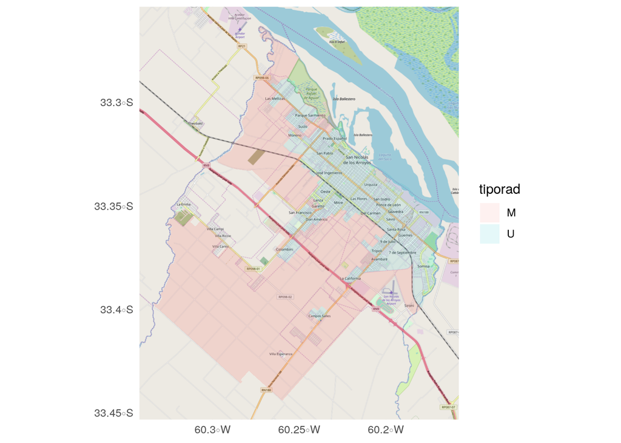

```r
SNVC <- ciudades %>%
    filter(eph_aglome == "San Nicolas - Villa Constitiución")



ggplot(SNVC) +
    annotation_map_tile(zoom = 13) +
    geom_sf(aes(fill = tiporad), alpha = .1, color = NA) +
    theme_minimal()
```

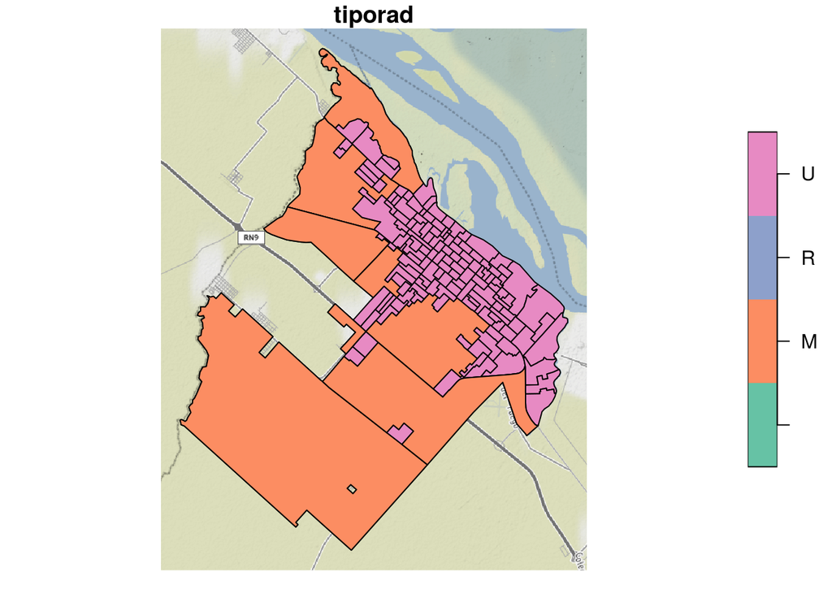

```r
library(ggmap)

bbox_SNVC <-  SNVC %>%
    st_coordinates() %>%
    as.tibble() %>%
    {make_bbox(.$X, .$Y)}

basemap <- get_stamenmap(bbox_SNVC, zoom = 12)

plot(st_transform(SNVC, crs = 3857)["tiporad"], bgMap = basemap)
```

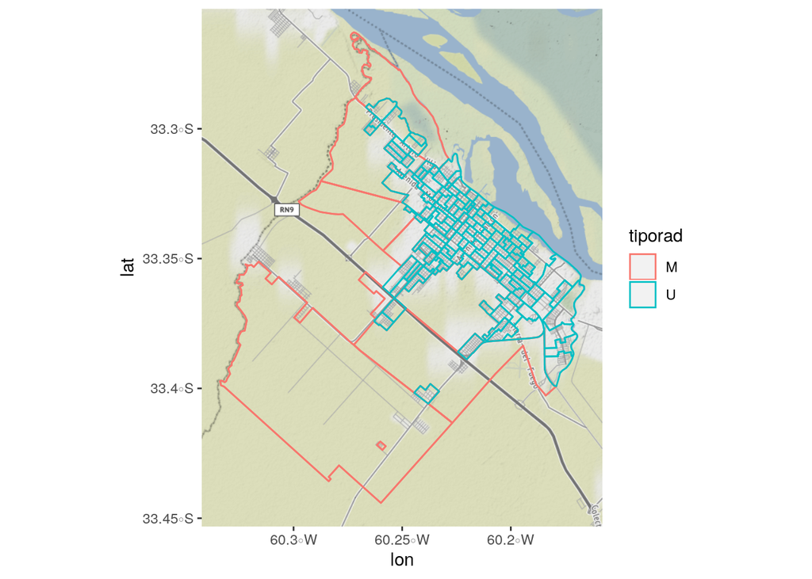

```r
ggmap(basemap) +
  coord_sf(crs = st_crs(3857)) + # force the ggplot2 map to be in 3857
  geom_sf(data = SNVC, aes(color = tiporad), fill = NA, alpha = .1, inherit.aes = FALSE)
```

## Estimando distancia desde cada radio censal Urbano hasta el espacio verde más cercano

Retenemos sólo radios urbanos

```r
ciudades <- ciudades %>%
    filter(tiporad == "U")
```

Pasamos todo a proyección equiareal para cálculo preciso, y medimos distancias

```r
areas_verdes <- st_read("../../Datasets/ambiente/areas_verdes_argentina.geojson") %>%
  st_transform(crs = "+proj=laea +lat_0=-40 +lon_0=-60 +x_0=0 +y_0=0 +ellps=WGS84 +units=m +no_defs")

ciudades <- st_transform(ciudades, crs = "+proj=laea +lat_0=-40 +lon_0=-60 +x_0=0 +y_0=0 +ellps=WGS84 +units=m +no_defs")

library(nngeo)

centroide_radios <- st_centroid(ciudades)

distancias <- st_nn(centroide_radios, areas_verdes, returnDist = TRUE)
saveRDS(distancias, file = "distancias.RDS")
```